# Safety Plan Fraser 2025

Al Irvine

Al Irvine  
New Graph Environment Ltd.  
al@newgraphenvironment  
250-777-1518  
Date Original: 2025-07-30  
Date Revised: 2025-09-10

# Safety Plan - 2025-076-sern-skeena-fraser-fish-passage

The latest version of this pdf can be downloaded [here](https://github.com/NewGraphEnvironment/safety_plan_fraser_2025/blob/main/docs/safety_plan_sern_fraser_2025.pdf).

## Check In Procedures

Call, text, or InReach Tara Stark (2505059854) each morning to share the plan for the day (i.e. name of roads and sites). Check in time is before 7pm each evening although we regularly check in throughout the day (ex. at arrival to site, 1pm and 4pm) on the InReach or by text and report position/provide updates.

### Procedures for Failed Check-In - for Check in person

Procedures are summarized in Figure 1. If phone call or InReach check-in is not received by 7pm send text to InReach units, call or text cell phones of field crew members. If no response please call accommodations then personal emergency contacts to see if they have heard anything. Wait 1 hour and text InReach, text or call cell phones and personal emergency contacts and accommodations again. Repeat after 2 hours (9 pm) - if no response then notify the RCMP of a missing persons in field.

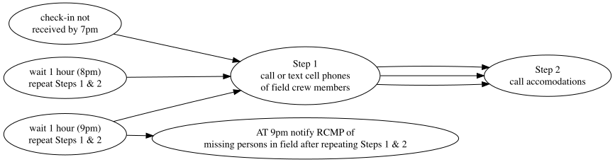

Figure 1: Procedures for failed check-in

## New Graph Environment Employee Information

Al Irvine  
Vehicle: 2013 Toyota Tundra black w/flatdeck and yellow can-am quad  
Accommodations: 3396 Rosia Road, Prince George, BC V2K 4Y5  
170 7th Avenue, Burns Lake, BC, V0J 1E2

Lucy Schick  
Vehicle: 2006 Pontiac Vibe red  
Accommodations: 3990 Larisa Court, Prince George, BC V2K 0B1  
170 7th Avenue, Burns Lake, BC, V0J 1E2

## Collaborating Crew Members

New Graph Employees Al Irvine and Lucy Schick may be joined by other groups/individuals from the area. All crew member information and emergency contacts can be found below.

Table 1: Crew members details and emergency contacts

| name | email | phone | satellite | emerg_name | emerg_email | emerg_phone |
| --- | --- | --- | --- | --- | --- | --- |
| Allan Irvine | al@newgraphenvironment.com | 250-777-1518 | must be contacted by inreach first. Cannot cold call | Tara Stark | tara@newgraphenvironment.com | 250-505-9854 |
| Lucy Schick | lucy@newgraphenvironment.com | 604-741-2032 | 807-790-9843 | Sa Boothroyd | saboothroyd@gmail.com | 604-740-7199 |

## Nearest Hospitals

[figure not shown]

Figure 2: University Hospital of Northern British Columbia - 1475 Edmonton St., Prince George, BC V2M 1S2 - 250-565-2000

[figure not shown]

Figure 3: G.R. Baker Memorial Hospital - 543 Front St, Quesnel, BC V2J 2K7 - 250-985-5600

## Emergency Response Plan

New Graph Environment’s detailed emergency response procedures can be found [here](https://www.newgraphenvironment.com/hsp/plans-and-assessments.html#emergency-response-plan-erp-and-procedures). These procedures should be reviewed and an emergency response plan should be completed for each job site. Our Emergency Responce Plan template can be downloaded [here](https://github.com/NewGraphEnvironment/hsp/blob/master/data/form_templates/ERP_template.pdf).

## Driving

We will be driving on forest service roads where it is essential to exercise caution and adhere strictly to all radio use protocols to ensure our safety. Proper communication on these roads helps prevent accidents by keeping everyone informed about vehicle movements and road conditions. Please review the [resource road safety](https://www.newgraphenvironment.com/hsp/safe-work-procedures-and-practices.html#resource-road-safety) and [radio use](https://www.newgraphenvironment.com/hsp/safe-work-procedures-and-practices.html#radio-use) sections of our Health and Safety plan so that everyone stays safe.

## 0.1 Project Overview

This project has two primary goals. The first is to conduct fish passage (Phase 1) and habitat confirmation (Phase 2) assessments within the Tabor River, Willow River, and Lower Salmon River watershed groups. The second goal is to implement baseline monitoring at previously assessed and/or remediated crossings in the Nechako River, Upper Fraser River, Morkill River, and Francois Lake watershed groups. Fieldwork will include electrofishing at permitted sites and collection of environmental DNA (eDNA) samples.

A summary of potential sites for fish passage assessments, habitat confirmation assessments, and electrofishing is provided in Table 7 and Figure 4. Google Earth (KML) and Garmin (GPX) files for the proposed sites are available for download [here](https://github.com/NewGraphEnvironment/safety_plan_fraser_2025/raw/main/docs/sites_fraser_2025_20250910_kml_gpx.zip).

## Equipment Checklists

PLEASE NOTE THAT EQUIPMENT CHECKLISTS ARE PROVIDED FOR THE OVERALL TEAM AND NOT ALL CREWS ARE REQUIRED TO HAVE ALL EQUIPMENT. ALTHOUGH ENCOURAGED FOR ALL ENVIRONMENTAL SCIENCE TECHNICIANS AND MONITORS TO HAVE THE PERSONAL EQUIPMENT NEW GRAPH ENVIRONMENT WILL HAVE ALL EQUIPMENT NECESSARY TO COMPLETE THE WORK.

MINIMUM REQUIREMENTS FOR EACH CREW MEMBER INCLUDES GOOD QUALITY AND APPROPRIATELY FITTING LIGHT WEIGHT WADERS AND SEPERATE WADING BOOTS (RUBBER SOLED), HAT, WATER AND A FOOD.

MINIMUM REQUIREMENTS FOR FIELD TRUCKS INCLUDE A QUALITY RADIO APPROPRIATE FOR FOREST SERVICE ROADS, OFF-ROAD CAPABLE TIRES IN GOOD CONDITION, SPARE TIRE, JACK, AND TOOLS.

Table 2: Personal Equipment Checklist - SEE NOTE ABOVE FOR MINIMUM REQUIREMENTS

Equipment

GPS

Suncreen

Bugspray

Polarized glasses

Bear Spray

phone/camera

battery pack booster for phone

Hat

first aid kit personal

Waders

Wading Boots (Rubber-soled only)

Ski poles

water

food

gloves work

headlamp

clinometer

field vest (surveyors)

note book

Extra clothes

rain gear

hand lens

range finder

–

Table 3: Crew Equipment Checklist - SEE NOTE ABOVE FOR MINIMUM REQUIREMENTS

Crew Equipment Checklist

glasses safety

Oakton Multimeter

Hand saw

Backpack Electrofisher

stop nets x 4

salt blocks

loose salt

dip nets x 2

Linesman Gloves x 3

tape measure hand

tape measure eslon

pilon x 2

Measuring board

Scale

Permits

Backroads Mapbook

Locational maps

Fish ID book

Background Documents

radio handheld

Satelite communicator

Field Safety Plan

first aid kit level 1

First Aid binder stocked

Site Cards / Field Guide

Minnow Traps

Catfood

Flagging

Laptop w/basecamp

GPS cable

Lazer level

Assessment cards fish passage

UAV radio

UAV

UAV landing pad

UAV GC tape

UAV safety plan (when required)

UAV registration

UAV license

UAV radio license

UAV backpack

Flow meter

ATV

Throw bags

polaski

shovel

fire extinguisher backpack

fire extinguisher pressurized

bucket rigid x 2

bucket foldable

clove oil kit w/ instructions

gloves leather

hard hat

steel toed boots

sharpies

ATV gas

ATV lock

UAV battery charger

wader disinfectant kit

GPS batteries

ATV helmets

Battery booster

Compressor 12V

Rubber boots (no-slip soles)

Small BT Speaker (for bears)

large backpack

–

–

Table 4: eDNA Equipment Checklist - SEE NOTE ABOVE FOR MINIMUM REQUIREMENTS

eDNA Equipment Checklist

field vest (surveyors)

note book

GPS

eDNA sampler

Car adaptor for charging eDNA batteries

Aluminium filter membrane housings x10

Filters

Extra hose

Nalgene bottles

Bleach Decontamination Bottle

Rinse bottle

Forceps/tweezers

95% ethanol

Colman cooler

Ice

Silica beads

Coin envelopes

Ziploc snack bags -medium

Ziploc snack bags -large

Nitrile gloves

3 jars/bowl/cups

–

–

–

Table 5: CABIN Equipment Checklist - SEE NOTE ABOVE FOR MINIMUM REQUIREMENTS

CABIN Equipment Checklist

clinometer

field vest (surveyors)

note book

GPS

phone/camera

Waders

Wading Boots (Rubber-soled only)

Turbidity Meter LaMotte 2020e

bucket rigid x 2

sharpies

wader disinfectant kit

GPS batteries

Colman cooler

Ice

Ziploc snack bags -medium

CABIN field sheets

clipboard

Gloves (rubber, neoprene)

Inside bottle waterproof label - use waterproof paper

Duct tape and tool kit

Densiometer

Velocity metre OR Meter stick

Measuring Tape

15 or 30cm ruler

Hand Level

Calculator

Tent pegs

CABIN Benthic Kick Net

Sieve

White tray

Squeeze Bottles

Spoon/tweezers

Bucket

Cabin sample jars

Formalin

–

Table 6: Truck Equipment Checklist - SEE NOTE ABOVE FOR MINIMUM REQUIREMENTS

Equipment

Hand saw

radio truck

Satelite communicator

first aid kit level 1

polaski

shovel

fire extinguisher backpack

truck tow rope

truck/car jack

Battery booster

Compressor 12V

pilon x 2

Tow strap

cloth or paper towel

–

–

## Field Plan

Fieldwork will focus on baseline monitoring in the Nechako River, Upper Fraser River, Morkill River, and Francois Lake watershed groups, and fish passage (Phase 1) and habitat confirmation (Phase 2) assessments in the Tabor River, Willow River, Lower Salmon River. Activities will include electrofishing at permitted sites and the collection of environmental DNA (eDNA) samples. Crews from McLeod Lake Indian Band and other partners will support the fieldwork.

Fieldwork methods will result in products feeding reporting formats such as our [2023/2024](https://www.newgraphenvironment.com/fish_passage_fraser_2023_reporting/) report. We generally follow procedures in:

- [fish passage assessments](https://www2.gov.bc.ca/assets/gov/environment/natural-resource-stewardship/land-based-investment/forests-for-tomorrow/field-assessment-for-determining-fish-passage-status-of-cbs.pdf) (Ministry of Environment 2011)
- [habitat confirmations](https://www2.gov.bc.ca/assets/gov/environment/natural-resource-stewardship/land-based-investment/forests-for-tomorrow/checklist-for-fish-habitat-confirmation-201112.pdf) (Fish Passage Technical Working Group 2011).

Information on fish presence/absence, species composition, density, and distribution limits is useful for prioritizing crossings for fish passage restoration and informing follow-up monitoring. To support this, electrofishing, minnow trapping, and eDNA sampling may be conducted where appropriate. Standard Fish and Fish Habitat Inventory Field Forms ([site cards](https://www2.gov.bc.ca/gov/content/environment/natural-resource-stewardship/laws-policies-standards-guidance/inventory-standards/aquatic-ecosystems)) are used to collect habitat data. The field guide for completing these forms is available [here](https://www2.gov.bc.ca/assets/gov/environment/natural-resource-stewardship/nr-laws-policy/risc/sitecard20.pdf).

Passive Integrated Transponder (PIT) tagging equipment is available and may be used to mark fish captured at electrofishing sites. Tagging can support long-term monitoring by providing data on population size and fish movement upstream and downstream of crossings. An overview of the tagging process is available [here](https://www.youtube.com/watch?v=9CKZ9yaS5o8). To anesthetize fish prior to PIT tagging, we use a clove oil solution at 0.1mL/L (1:10,000), which provides effective sedation with minimal residual effects (Fernandes et al. 2017). The solution is prepared by dissolving clove oil in ethyl alcohol at a 1:9 ratio before mixing into water (Fernandes et al. 2017).

Digital field forms are used to collected data, utilizing [Mergin Maps](https://merginmaps.com/?gclid=Cj0KCQjwxb2XBhDBARIsAOjDZ34oq-iMid3vRrgK1ZAkJ_yiz4aWY-LLF90PHiXzELbZIrxooV9vWKYaAgl2EALw_wcB), which syncs with QGIS and supports offline use. Instructions for setting up Mergin Maps and using the digital field forms can be found in the [Fish Passage Guidebook](https://www.newgraphenvironment.com/fish_passage_guidebook/). Users should send their Mergin usernames to enable project sharing and form access.

A field guide to freshwater fish identification, such as *Field Key to the Freshwater Fishes of British Columbia* by McPhail and Carveth (1993), can be useful during fieldwork. It is available for download [here](https://a100.gov.bc.ca/pub/acat/documents/r13659/486FieldKeytoFreshwaterFishes1993Part1of2_1210014849226_8e248a8d30d97e6c45ef54a340babd2ffb57b14a3b16.pdf).

[figure not shown]

Figure 4: Map of potential sampling areas.

Table 7: Potential Phase 1 assessment, Phase 2 assessment, and Electrofishing Locations

| id | stream_name | utm_zone | utm_easting | utm_northing | watershed_group_code | pscis_assessment_comment |
| --- | --- | --- | --- | --- | --- | --- |
| 7622 | Burnt Cabin Creek | 10 | 388738 | 5997154 | FRAN | The culvert is undersized for current flow volumes, as indicated by the 1.15m outlet drop. The local name of the stream is Burnt Cabin Creek. A landowner adjacent to the crossing downstream on Gala Ba… |
| 126267 | Stephanie Cr. | 10 | 583374 | 5911978 | WILL | – |
| 126290 | Hay Creek | 10 | 537250 | 5991350 | WILL | – |
| 126316 | Wansa Creek | 10 | 551588 | 5970657 | WILL | – |
| 196051 | Unnamed | 10 | 526285 | 5978523 | TABR | – |
| 196072 | Cale Creek | 10 | 522679 | 5956610 | TABR | – |
| 196085 | Tabor Creek | 10 | 518502 | 5962002 | TABR | Fish observed at outlet. |
| 196151 | Cale Creek | 10 | 524160 | 5957999 | TABR | Beaver dam at inlet. |
| 196201 | Haggith Creek | 10 | 521127 | 5965112 | TABR | 14m fill depth. |
| 196207 | Hudson Bay Slough | 10 | 516996 | 5972733 | TABR | Outlet control. |
| 196264 | Parkridge Creek | 10 | 515025 | 5966533 | TABR | – |
| 196328 | Archer Creek | 10 | 573972 | 5894796 | WILL | – |
| 196340 | Slough Creek | 10 | 590481 | 5882133 | WILL | – |
| 199171 | Burnt Cabin Creek | 10 | 388946 | 5997015 | FRAN | The local name of the stream is Burnt Cabin Creek. A large outlet drop and a heavily eroded outlet pool indicated the culvert was undersized. The stream provided complex habitat with abundant cover. T… |
| 199172 | Scotch Creek | 10 | 388276 | 5996950 | FRAN | The culvert was very undersized for the stream, as indicated by the large outlet drop. The stream had a good amount of given the time of year and uncharacteristically dry year. Habitat was of medium v… |
| 199173 | Tributary To Nechako River | 10 | 398938 | 5996429 | NECR | The culvert had a moderate outlet drop with some erosion around the pipe at the outlet. The pipe was in good condition. The stream provided excellent habitat, with several pools and abundant undercut … |
| 199190 | Clear Creek | 10 | 425562 | 5996164 | NECR | The bottom of the culvert had been reinforced with concrete, likely to address holes noted in the previous assessment. A large pile of riprap was placed at the outlet, possibly to reduce the outlet dr… |
| 199237 | Snowshoe Creek | 10 | 650785 | 5934863 | MORK | The culvert had a deep outlet pool and a very large outlet drop. The stream contained functional large woody debris creating complex cover and pools.No photos are available because the surveyors phone… |
| 199260 | Tributary To Sugarbowl Creek | 10 | 587921 | 5972451 | MORK | The culvert had a significant 1.4m outlet drop, and inlet drop due to a small debris jam. The stream flowed through mature old-growth forest and provided high-quality habitat with steep gradients, ste… |
| 199267 | Driscoll Creek | 10 | 606373 | 5965783 | MORK | The culvert had a deep outlet pool and a very large outlet drop. The stream was banked with a well-developed, healthy, riparian zone consisting of old-growth forest. A beaver dam was located just upst… |
| 199278 | Teepee Creek | 11 | 344034 | 5862741 | UFRA | A moderate outlet drop was present and would be substantial at lower flows. Flow was steady at the time of assessment. The culvert was in good condition. A large, deep outlet pool indicated the culver… |
| 12200024 | – | 10 | 515409 | 5989806 | LSAL | – |
| 12202167 | – | 10 | 496209 | 5999657 | LSAL | – |
| 19702777 | – | 10 | 517279 | 5936628 | TABR | – |
| 19703257 | Tabor Creek | 10 | 518845 | 5961982 | TABR | – |
| 19703286 | Bittner Creek | 10 | 521864 | 5976392 | TABR | – |
| 19703295 | – | 10 | 526448 | 5985791 | TABR | – |
| 19703303 | Bertschi Creek | 10 | 522978 | 5980978 | TABR | – |
| 19703358 | Trapping Creek | 10 | 520105 | 5935908 | TABR | – |
| 24400646 | Rucheon Creek | 10 | 577020 | 5886032 | WILL | – |
| 24401504 | Tsadestsa Creek | 10 | 536470 | 5981315 | WILL | – |
| 24401692 | – | 10 | 541465 | 5981577 | WILL | – |
| 24402183 | – | 10 | 541358 | 5981709 | WILL | – |
| 24723694 | Cale Creek | 10 | 521645 | 5955176 | TABR | – |
| 24723695 | Red Rock Creek | 10 | 521513 | 5949553 | TABR | – |
| 24727190 | Wansa Creek | 10 | 556416 | 5962053 | WILL | – |

# References

Fernandes, I. M., Y. F. Bastos, D. S. Barreto, L. S. Lourenço, and J. M. Penha. 2017. “The Efficacy of Clove Oil as an Anaesthetic and in Euthanasia Procedure for Small-Sized Tropical Fishes.” *Brazilian Journal of Biology = Revista Brasleira De Biologia* 77 (3): 444–50. https://doi.org/10.1590/1519-6984.15015.

Fish Passage Technical Working Group. 2011. “A Checklist for Fish Habitat Confirmation Prior to the Rehabilitation Fo a Stream Crossing.” https://www2.gov.bc.ca/assets/gov/environment/natural-resource-stewardship/land-based-investment/forests-for-tomorrow/checklist-for-fish-habitat-confirmation-201112.pdf.

McPhail, J. D., and R Carveth. 1993. “Field Key to the Freshwater Fishes of British Columbia.” https://www2.gov.bc.ca/assets/gov/environment/natural-resource-stewardship/nr-laws-policy/risc/field_key_to_freshwater_fishes_of_bc_field_size_water_resistant_version.pdf.

Ministry of Environment. 2011. “Field Assessment for Determining Fish Passage Status of Closed Bottom Structures.” BC Ministry of Environment (MoE). https://www2.gov.bc.ca/assets/gov/environment/natural-resource-stewardship/land-based-investment/forests-for-tomorrow/field-assessment-for-determining-fish-passage-status-of-cbs.pdf.